# Wordle

## 第一问

### 题目概览

**English**

The number of reported results vary daily. Develop a model to explain this variation and use your model to create a prediction interval for the number of reported results on March 1, 2023. Do any attributes of the word affect the percentage of scores reported that were played in Hard Mode? If so, how? If not, why not?

**中文**

报告结果的数量每天都在变化。建立一个模型来解释这种变化，并使用你的模型为2023年3月1日的报告结果数量建立一个预测区间。词语的任何属性是否影响到报告的在困难模式下进行的分数的百分比？如果是，如何影响？如果没有，为什么没有？

- 建立模型，解释变化原因、建立预测区间
- 分析词语的属性是否影响了report number of hard/totol report number, 解释原因

### 解题思路

#### 报告结果数量的时间序列模型

**数据展示与数据预处理**

- 展示原始数据
- 预处理
  - 异常值处理（异常单词，异常数据）
  - 对数变换
  - 训练集测试集划分

**模型选择**

- 原始数据特征分析
- Prophet特点及选择理由

**模型配置与训练**

- Prophet参数设置（置信区间很重要）
- 测试集合推理预测结果（带holiday、不带holiday）
  - 重点分析此时的结果图，可以解释每日报告数量变化的来源（参考[理论部分](https://www.zhihu.com/question/21229371)）

**模型评估与结论**

### 报告结果数量的时间序列模型

#### 数据展示与数据预处理

先展示原始数据

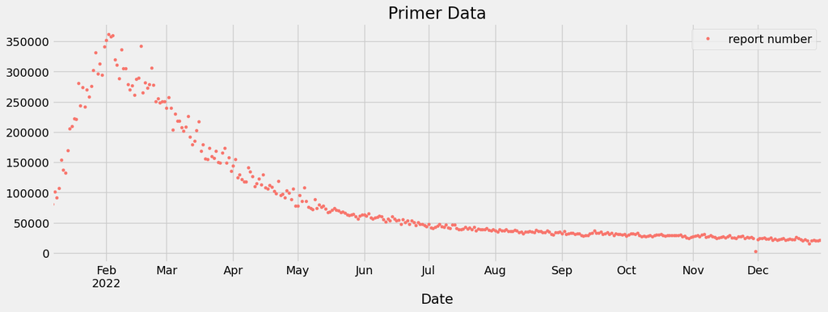

```python
import pandas as pd
import numpy as np
import matplotlib.pyplot as plt
import os
import json
import statsmodels.graphics.tsaplots as tsaplots
from statsmodels.tsa.stattools import adfuller
import seaborn as sns

# DIRS
DATA_DIR = "data"
IMG_DIR = "img"
WORDLE_DATA_FILE = os.path.join(DATA_DIR, "Problem_C_Data_Wordle.xlsx")
PROD_DATA_FILE = os.path.join(DATA_DIR, "data.xlsx")
# Color pallete for plotting
color_pal = ["#F8766D", "#D39200", "#93AA00",
             "#00BA38", "#00C19F", "#00B9E3",
             "#619CFF", "#DB72FB"]
# plt.style.use('ggplot')
# plt.style.use('seaborn')
plt.style.use('fivethirtyeight')

df = pd.read_excel(WORDLE_DATA_FILE)
df = df[['Date', 'Total-num-repo']]
df.columns = ['Date','report number']
df = df.sort_values(by='Date', ascending=True)
df.reset_index(drop=True, inplace=True)
df.set_index('Date').plot(style='.', figsize=(15,5), color=color_pal[0], title='Primer Data')
plt.figure(dpi=150)
plt.show()
```

我们将创造一些时间序列特征，看看趋势是如何受到星期、季度、月度等影响的。

```python
def create_features(df, label=None):
    """
    Creates time series features from datetime index.
    """
    df = df.copy()
    df['date'] = df.index
    df['dayofweek'] = df['Date'].dt.dayofweek
    df['quarter'] = df['Date'].dt.quarter
    df['month'] = df['Date'].dt.month
    df['dayofyear'] = df['Date'].dt.dayofyear
    df['dayofmonth'] = df['Date'].dt.day
    df['weekofyear'] = df['Date'].dt.isocalendar().week

    X = df[['dayofweek','quarter','month',
           'dayofyear','dayofmonth','weekofyear']]
    if label:
        y = df[label]
        return X, y
    return X

df = pd.read_excel(PROD_DATA_FILE)
df = df[['Date', 'Total-num-repo']]
df = df.sort_values(by='Date', ascending=True)
df.reset_index(drop=True, inplace=True)
X, y = create_features(df, label='Total-num-repo')

features_and_target = pd.concat([X, y], axis=1)
print(features_and_target)
```

```
     dayofweek  quarter  month  dayofyear  dayofmonth  weekofyear  \
0            4        1      1          7           7           1
1            5        1      1          8           8           1
2            6        1      1          9           9           1
3            0        1      1         10          10           2
4            1        1      1         11          11           2
..         ...      ...    ...        ...         ...         ...
354          1        4     12        361          27          52
355          2        4     12        362          28          52
356          3        4     12        363          29          52
357          4        4     12        364          30          52
358          5        4     12        365          31          52

     Total-num-repo
0             80630
1            101503
2             91477
3            107134
4            153880
..              ...
354           20879
355           20160
356           20001
357           21204
358           20380

[359 rows x 7 columns]
```

**Plotting the Features to see trends**

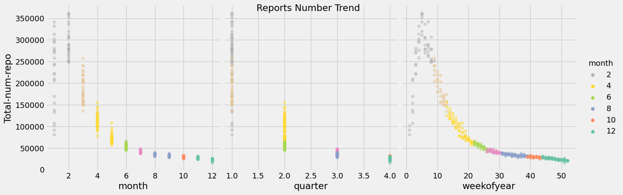

```python
sns.pairplot(features_and_target.dropna(),
             hue='month',
             palette="Set2_r",
             x_vars=['month',
                     'quarter','weekofyear'],
             y_vars='Total-num-repo',
             height=5,
             plot_kws={'alpha':0.5, 'linewidth':0},
            )
plt.suptitle('Reports Number Trend')
plt.show()
```

**数据预处理**

- 异常值处理

我们发现11月30日 study的report总数为2569，困难模式的report数量为2405，而相近日期的report总数都在2万左右，困难模式占总数的1/10左右，study对应的数据明显是错误数据，我们选择使用相邻日的均值作为插值替代处理。经过处理以后的数据展示如下。

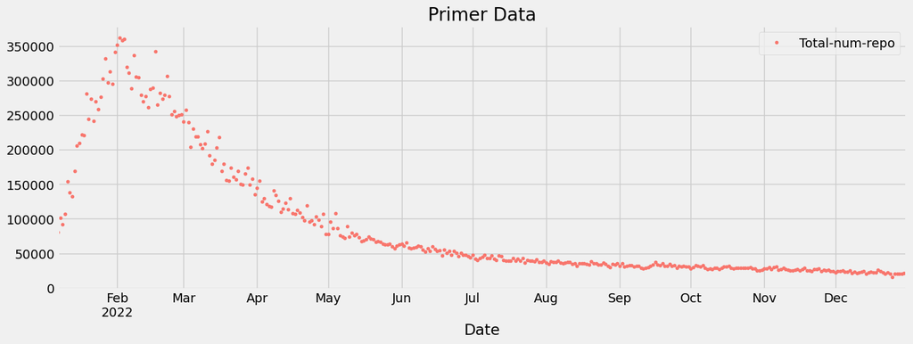

```python
df = pd.read_excel(PROD_DATA_FILE)
df = df[['Date', 'Total-num-repo']]
df = df.sort_values(by='Date', ascending=True)
df.reset_index(drop=True, inplace=True)
plt.figure(dpi=150)
df.set_index('Date').plot(style='.', figsize=(15,5), color=color_pal[0], title='Primer Data')
plt.show()
```

- 对数变换

> 作用：

> 1.数据平稳化：对于具有明显趋势或周期性的数据，进行对数变换可以将其转换为平稳的数据序列。平稳的数据序列更容易建立预测模型，且能够避免一些常见的时间序列分析问题，如异方差性和非常数波动。

> 2.变换为线性关系：对于非线性关系的数据，进行对数变换可以将其转换为线性关系，使得建立预测模型更加简单。例如，对于指数增长的数据，进行对数变换可以将其转换为线性增长，使得可以使用线性回归模型进行分析

> 3.改善预测精度：对数变换可以将数据的比例关系转换为差异关系，从而能够更好地处理数据中的离群值或极端值。同时，对于呈现指数增长或减少趋势的数据，进行对数变换可以降低数据的波动性，从而使得预测结果更加准确。

> 总之，对数变换是一种常见的数据预处理方法，能够帮助我们更好地理解和处理数据，以及建立更加准确的预测模型。但是需要注意的是，对数变换可能会对数据的实际含义造成一定的影响，因此在使用时需要谨慎考虑。

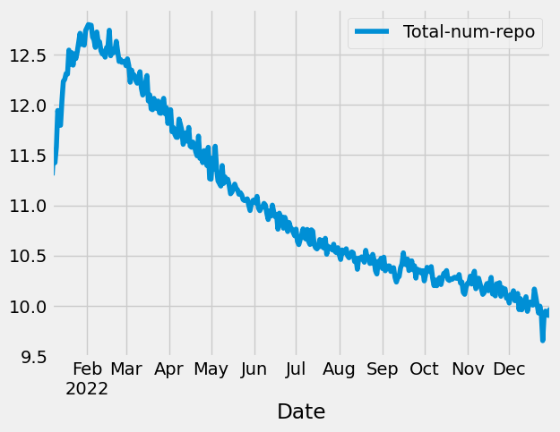

```python
df['Total-num-repo'] = np.log(df['Total-num-repo'])
df.set_index('Date').plot();
plt.show()
```

- 训练集测试集划分

一共有12个月的数据，我们将前11个月的数据作为训练集用于模型训练，最后一个月的数据作为测试集进行验证。

```
[]
```

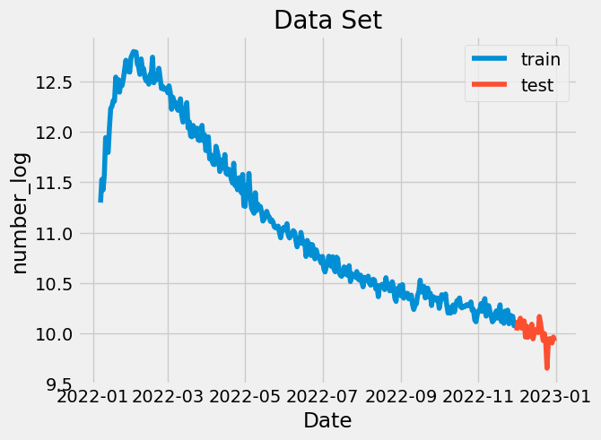

```python
train_df = df[df['Date'] < '2022-12-01']
test_df = df[df['Date'] >= '2022-12-01']
plt.plot(train_df['Date'], train_df['Total-num-repo'], label="train")
plt.plot(test_df['Date'], test_df['Total-num-repo'], label="test")
plt.title("Data Set")
plt.xlabel("Date")
plt.ylabel("number_log")
plt.legend()
plt.plot()
```

#### 模型选择

时间序列预测模型可以考虑使用ARIMA、prophet等。

Prophet模型和ARIMA模型都是用于时间序列预测的常用模型，它们各有优势，下面是一些Prophet模型相对于ARIMA模型的优势：

- 容易使用：Prophet模型相对于ARIMA模型来说更加易于使用，不需要太多的数学背景知识和专业技能，可以更快速地进行建模和预测。
- 更好的处理季节性和节假日效应：Prophet模型专门设计用于处理具有强烈季节性和节假日效应的时间序列数据，而ARIMA模型则需要手动指定这些效应。在处理复杂的时间序列数据时，Prophet模型可以更准确地捕捉和预测这些效应。
- 更好的处理缺失值和异常值：Prophet模型可以在数据中包含缺失值的情况下进行建模和预测，而ARIMA模型需要对缺失值进行额外的处理。此外，Prophet模型还可以更好地处理异常值，并通过指定一个阈值来控制异常值的影响。
- 更好的处理非线性趋势：Prophet模型可以捕捉到非线性的趋势，而ARIMA模型通常只能捕捉线性的趋势。这使得Prophet模型更适合处理具有复杂趋势的时间序列数据。

总之，Prophet模型和ARIMA模型各有优势，在实际使用中需要根据数据的特点选择合适的模型。

#### 模型参数配置与训练

建立Prophet-Normal模型和Prophet-Holiday模型，后者引入了holiday。

先来看Prophet-Normal模型

```
Importing plotly failed. Interactive plots will not work.
15:26:55 - cmdstanpy - INFO - Chain [1] start processing
15:26:55 - cmdstanpy - INFO - Chain [1] done processing
```

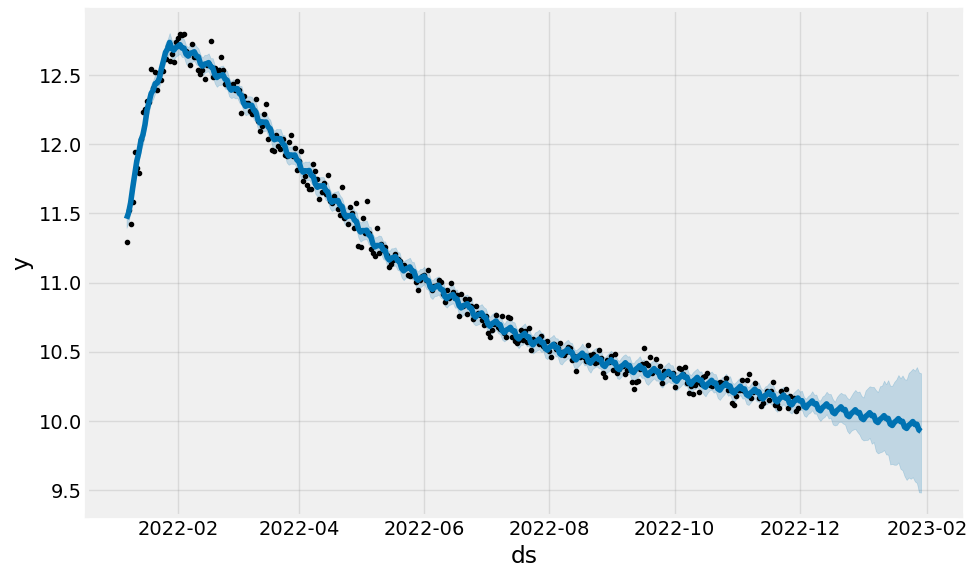

```python
from prophet import Prophet
train_df.columns = ["ds", "y"]
test_df.columns = ["ds", "y"]
m1 = Prophet(interval_width=0.7)
m1.fit(train_df)
future1 = m1.make_future_dataframe(periods=60)
forecast1 = m1.predict(future1)
forecast1[['ds', 'yhat', 'yhat_lower', 'yhat_upper']].tail()
m1.plot(forecast1)
plt.show()
```

下面是趋势图和每周的趋势

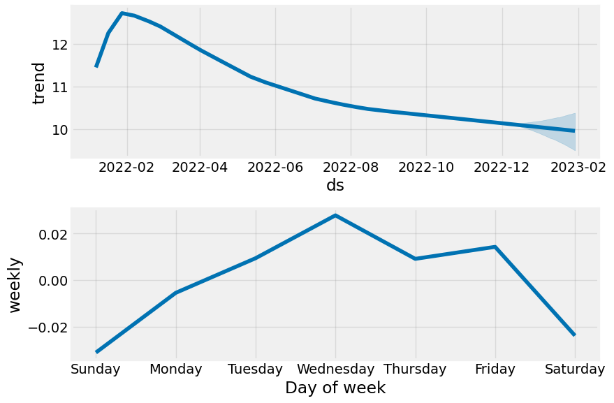

```python
m1.plot_components(forecast1)
plt.show()
```

下面是预测结果

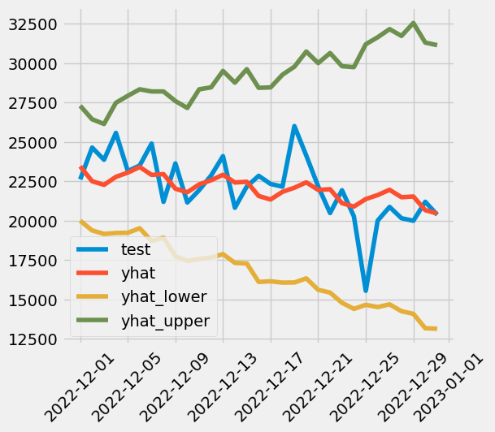

```python
predict = np.exp(forecast1[['yhat', 'yhat_lower', 'yhat_upper']])
real = np.exp(test_df['y'])
plt.plot(test_df['ds'], real, label='test')
plt.plot(test_df['ds'], predict['yhat'][-31:], label='yhat')
plt.plot(test_df['ds'], predict['yhat_lower'][-31:], label='yhat_lower')
plt.plot(test_df['ds'], predict['yhat_upper'][-31:], label='yhat_upper')
plt.tight_layout()
# x轴标签倾斜
plt.xticks(rotation=45)
plt.legend()
plt.show()
```

**Normal模型误差分析**

```python
from sklearn.metrics import mean_squared_error, mean_absolute_error
pred = predict['yhat'][-31:]
MSE = mean_squared_error(y_true=real,y_pred=pred) # MSE
MAE = mean_absolute_error(y_true=real,y_pred=pred) # MAE
def mean_absolute_percentage_error(y_true, y_pred):
    """Calculates MAPE given y_true and y_pred"""
    y_true, y_pred = np.array(y_true), np.array(y_pred)
    return np.mean(np.abs((y_true - y_pred) / y_true)) * 100
MAPE = mean_absolute_percentage_error(y_true=real,y_pred=pred)
print("MSE: ", MSE)
print("MAE: ", MAE)
print("MAPE: ", MAPE,"%")
```

```
MSE:  3109752.2861439753
MAE:  1312.5835091349788
MAPE:  6.146094242320282 %
```

接下来引入Holiday

```python
# from pandas.tseries.holiday import USFederalHolidayCalendar as calendar
# cal = calendar()
# train_holidays = cal.holidays(start=train_df.index.min(),
#                               end=train_df.index.max())
# test_holidays = cal.holidays(start=test_df.index.min(),
#                              end=test_df.index.max())
# df['ds'] = df.index.Date
# df['is_holiday'] = df.date.isin([d.date() for d in cal.holidays()])
# holiday_df = df.loc[df['is_holiday']] \
#     .reset_index() \
#     .rename(columns={'Datetime':'ds'})
# holiday_df['holiday'] = 'USFederalHoliday'
# holiday_df = holiday_df.drop(['Total-num-repo','Date','is_holiday'], axis=1)
# holiday_df['ds'] = pd.to_datetime(holiday_df['ds'])
# holiday_df.head()
articles = pd.DataFrame({
  'holiday': 'havefun',
  'ds': pd.to_datetime(['2022-01-01', '2022-01-17', '2022-02-02', '2022-02-14', '2022-02-21',
                       '2022-03-17', '2022-04-15', '2022-04-16', '2022-04-17', '2022-04-18',
                       '2022-05-05', '2022-05-08', '2022-05-30', '2022-06-19', '2022-07-04',
                       '2022-09-05', '2022-09-11', '2022-10-10', '2022-10-31', '2022-11-11',
                       '2022-11-24', '2022-11-25', '2022-12-24', '2022-12-25', '2022-12-31']),
  'lower_window': 0,
  'upper_window': 2,
})
articles.head()
```

|  | holiday | ds | lower_window | upper_window |
| --- | --- | --- | --- | --- |
| 0 | havefun | 2022-01-01 | 0 | 2 |
| 1 | havefun | 2022-01-17 | 0 | 2 |
| 2 | havefun | 2022-02-02 | 0 | 2 |
| 3 | havefun | 2022-02-14 | 0 | 2 |
| 4 | havefun | 2022-02-21 | 0 | 2 |

```
15:26:58 - cmdstanpy - INFO - Chain [1] start processing
15:26:58 - cmdstanpy - INFO - Chain [1] done processing
```

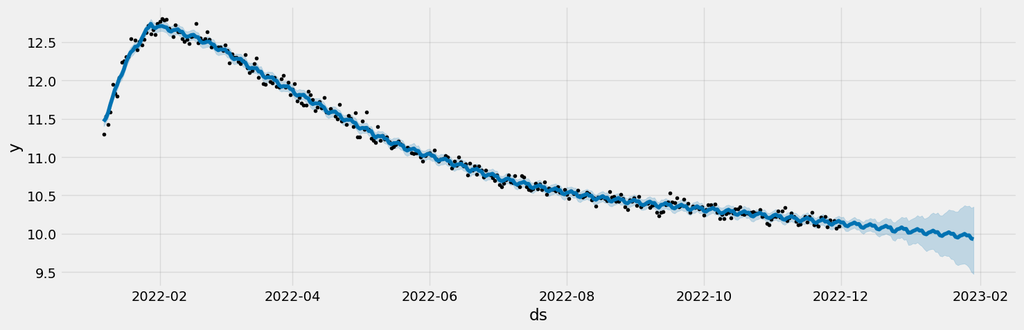

```python
m2 = Prophet(holidays=articles,interval_width=0.7).fit(train_df)
future2 = m2.make_future_dataframe(periods=60)
forecast2 = m2.predict(future2)
f, ax = plt.subplots(1)
f.set_figheight(5)
f.set_figwidth(15)
fig = m2.plot(forecast2,
                 ax=ax)
plt.show()
```

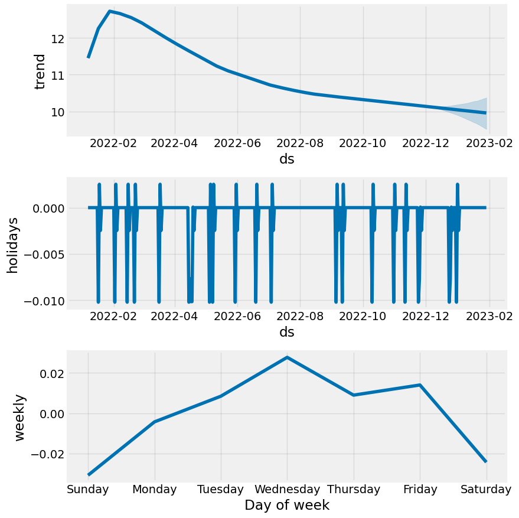

```python
m2.plot_components(forecast2);
plt.show()
```

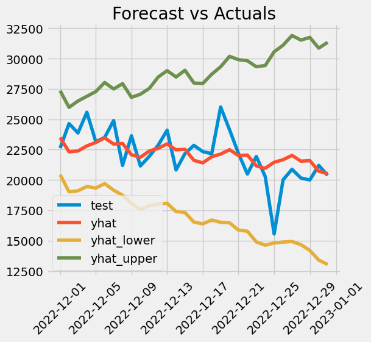

```python
predict = np.exp(forecast2[['yhat', 'yhat_lower', 'yhat_upper']])
real = np.exp(test_df['y'])
plt.plot(test_df['ds'], real, label='test')
plt.plot(test_df['ds'], predict['yhat'][-31:], label='yhat')
plt.plot(test_df['ds'], predict['yhat_lower'][-31:], label='yhat_lower')
plt.plot(test_df['ds'], predict['yhat_upper'][-31:], label='yhat_upper')
plt.tight_layout()
# x轴标签倾斜
plt.xticks(rotation=45)
plt.title('Forecast vs Actuals')
plt.legend()
plt.show()
```

```python
pred = predict['yhat'][-31:]
MSE = mean_squared_error(y_true=real,y_pred=pred) # MSE
MAE = mean_absolute_error(y_true=real,y_pred=pred) # MAE
def mean_absolute_percentage_error(y_true, y_pred):
    """Calculates MAPE given y_true and y_pred"""
    y_true, y_pred = np.array(y_true), np.array(y_pred)
    return np.mean(np.abs((y_true - y_pred) / y_true)) * 100
MAPE = mean_absolute_percentage_error(y_true=real,y_pred=pred)
print("MSE: ", MSE)
print("MAE: ", MAE)
print("MAPE: ", MAPE,"%")
```

```
MSE:  3155756.7947304435
MAE:  1318.1446547896908
MAPE:  6.185567993310769 %
```

**预测3月1日**

```
15:27:09 - cmdstanpy - INFO - Chain [1] start processing
15:27:09 - cmdstanpy - INFO - Chain [1] done processing
```

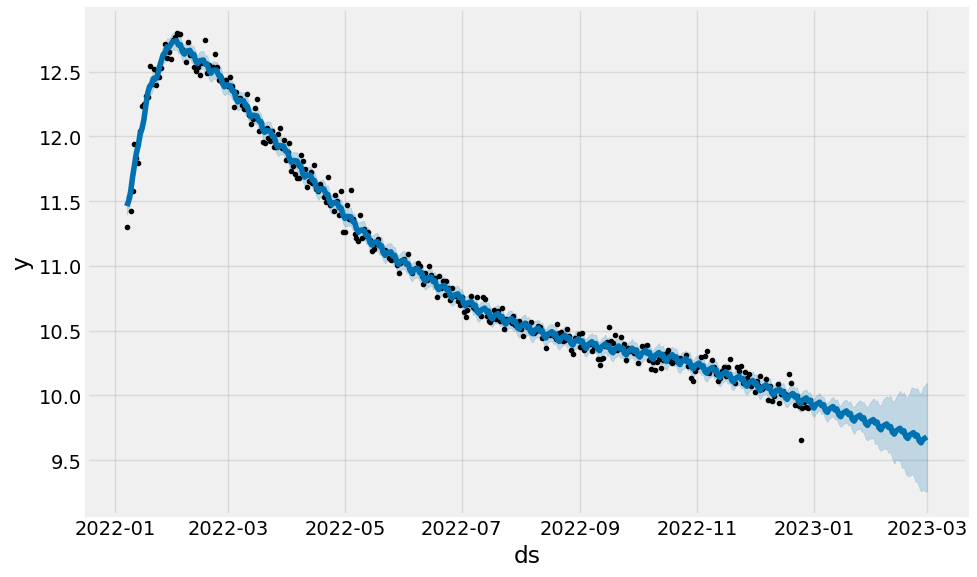

```python
df.columns = ["ds", "y"]
m3 = Prophet(interval_width=0.7)
m3.fit(df)
future3 = m3.make_future_dataframe(periods=60)
forecast3 = m3.predict(future3)
fig = m3.plot(forecast3)
plt.show()
```

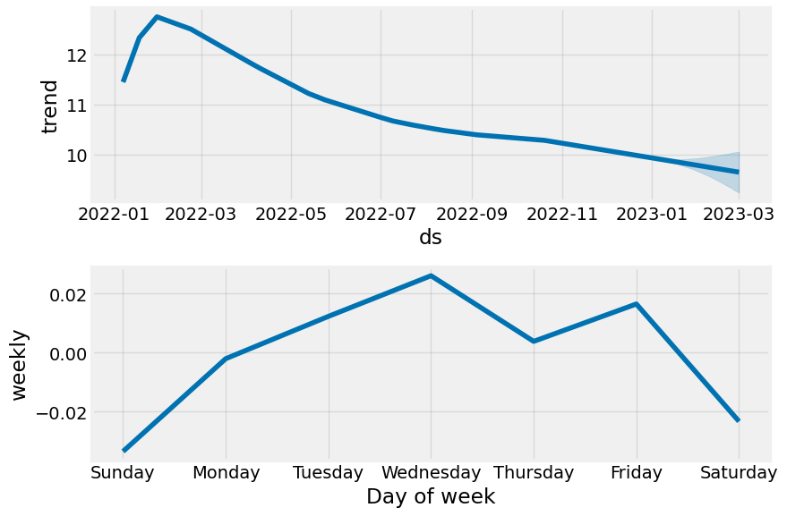

```python
m3.plot_components(forecast3);
plt.show()
```

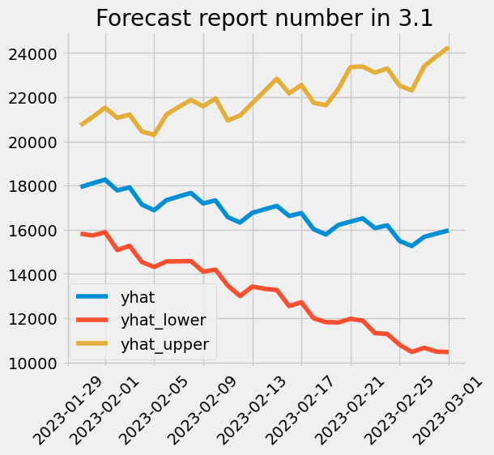

```python
predict = np.exp(forecast3[['yhat', 'yhat_lower', 'yhat_upper']])
plt.plot(forecast3['ds'][-31:], predict['yhat'][-31:], label='yhat')
plt.plot(forecast3['ds'][-31:], predict['yhat_lower'][-31:], label='yhat_lower')
plt.plot(forecast3['ds'][-31:], predict['yhat_upper'][-31:], label='yhat_upper')
plt.tight_layout()
# x轴标签倾斜
plt.xticks(rotation=45)
plt.title('Forecast report number in 3.1')
plt.legend()
plt.show()
```

最终的预测区间值为：

```python
# print last 1 day
print("yhat: ", predict['yhat'][-1:])
print("yhat_lower: ", predict['yhat_lower'][-1:])
print("yhat_upper: ", predict['yhat_upper'][-1:])
```

```
yhat:  418    15969.087129
Name: yhat, dtype: float64
yhat_lower:  418    10472.24395
Name: yhat_lower, dtype: float64
yhat_upper:  418    24253.129996
Name: yhat_upper, dtype: float64
```

**断点分析**

如何分析断点请参考：facebook[文档](https://facebook.github.io/prophet/docs/trend_changepoints.html#automatic-changepoint-detection-in-prophet)

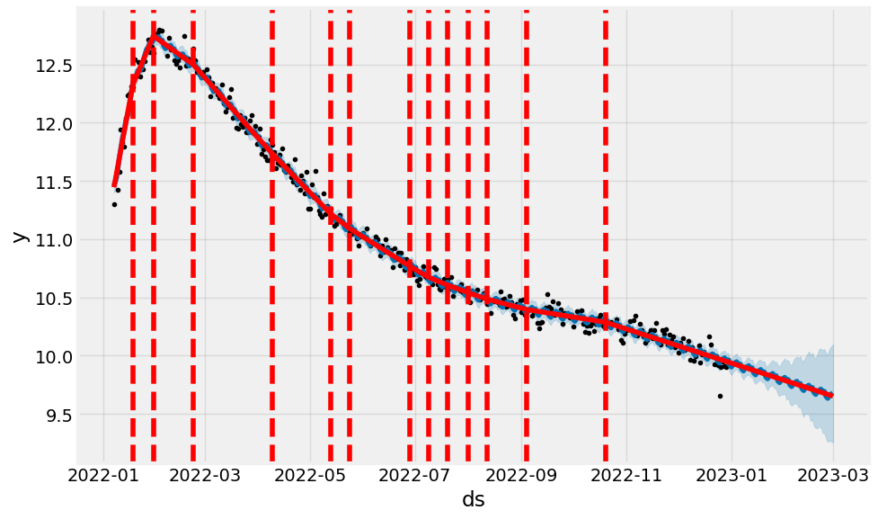

```python
from prophet.plot import add_changepoints_to_plot
fig = m3.plot(forecast3)
a = add_changepoints_to_plot(fig.gca(), m3, forecast3)
```

### 词语属性与选择困难模式比例的相关性分析

先考虑使用人为提取的特征进行相关性分析，再考虑使用word2vec进行相关性分析。

- 单词相关度聚类
- 词频：单词在语料库的出现频率
- 元音字母个数
- 首字母
- 重音位置
- 词性
- 词根
- 情感倾向
- 频率高的字母对单词赋权
- word2vec

prepare 1. **提取初始序列**

words 会作为相关性分析的X值，我们需要提取words序列，并计算其各种维度的特征

possibility会作为相关性分析的Y值，我们需要提取possibility序列

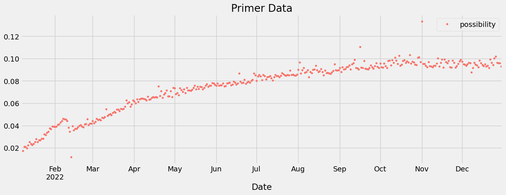

```python
df = pd.read_excel(PROD_DATA_FILE)
df = df.sort_values(by='Date', ascending=True)
df['possibility'] = df['Hard-num-repo']/df['Total-num-repo']
possibility = df['possibility']
words = df['Word']
df = df[['Date','possibility']]
df.reset_index(drop=True, inplace=True)
plt.figure(dpi=150)
df.set_index('Date').plot(style='.', figsize=(15,5), color=color_pal[0], title='Primer Data')
plt.show()
```

prepare 2. **提取特征**

导入已经预处理好的特征表

```python
K_MEAN_FILE = os.path.join(DATA_DIR, "k_means.json")
POSS_WORDS_FREQ =  os.path.join(DATA_DIR, "possible_words_freq.json")
POSS_WORDS_FREQ_SIGMOID = os.path.join(DATA_DIR, "possible_words_sigmoid.json")
POSS_WORDS_FILE = os.path.join(DATA_DIR, "possible_words.txt")
AEIOU = os.path.join(DATA_DIR, "aeiou.json")
FIRST_LETTER = os.path.join(DATA_DIR, "first_letter.json")
k_mean = json.load(open(K_MEAN_FILE))
freq = json.load(open(POSS_WORDS_FREQ))
freq_sigmoid = json.load(open(POSS_WORDS_FREQ_SIGMOID))
aeiou = json.load(open(AEIOU))
first_letter = json.load(open(FIRST_LETTER))
poss_words = []

def centerize(x):
    """
    对向量x进行中心化处理，即减去均值。

    参数：
    x: numpy array，需要进行中心化处理的向量

    返回：
    中心化后的向量
    """
    mean_x = np.mean(x)
    centered_x = x - mean_x
    return centered_x

def centerize_matrix(X):
    """
    对矩阵X的每一列进行中心化处理，即减去每一列的均值。

    参数：
    X: numpy array，需要进行中心化处理的矩阵

    返回：
    中心化后的矩阵
    """
    mean_X = np.mean(X, axis=0)
    centered_X = X - mean_X
    return centered_X

possibility = centerize(possibility)

with open(POSS_WORDS_FILE, "r") as f:
    for line in f:
        poss_words.append(line.strip())
```

1. 对K_means**单词编辑距离聚类**特征进行相关性分析

```python
import scipy.stats as stats
words_k_mean = centerize([k_mean[word] for word in words])
corr, pval = stats.pearsonr(words_k_mean, possibility)
# 输出Pearson相关系数和p值
print("words_k_mean Pearson correlation coefficient: ", corr)
print("p-value: ", pval)
```

```
words_k_mean Pearson correlation coefficient:  0.04713525841691162
p-value:  0.373215680799986
```

Pearson相关系数为0.047，接近于0，说明两个变量之间没有强烈的线性关系。这意味着当一个变量变化时，另一个变量不一定会随之变化。

需要注意的是，即使Pearson相关系数接近于0，仍然有可能存在非线性关系。此外，Pearson相关系数只能够检测两个变量之间的线性关系，如果存在其他类型的关系，如指数关系或幂关系，Pearson相关系数可能不适用。因此，在解释相关系数之前，需要仔细考虑数据的特征和相关性分析方法的适用性。

2. 对Freq**词频**特征进行相关性分析

```python
words_freq = centerize([freq[word] for word in words])
words_freq_sigmoid = [freq_sigmoid[word] for word in words]
corr, pval = stats.pearsonr(words_freq, possibility)
# 输出Pearson相关系数和p值
print("words_freq Pearson correlation coefficient: ", corr)
print("p-value: ", pval)

corr, pval = stats.pearsonr(words_freq_sigmoid, possibility)
# 输出Pearson相关系数和p值
print("words_freq_sigmoid Pearson correlation coefficient: ", corr)
print("p-value: ", pval)
```

```
words_freq Pearson correlation coefficient:  -0.10777561118190285
p-value:  0.04126247857751675
words_freq_sigmoid Pearson correlation coefficient:  -0.07995708810656435
p-value:  0.13050613858634996
```

因此，我们可以得出结论，这两个变量之间存在一定程度的负相关性，即当一个变量增加时，另一个变量可能会减少。

3. 对**元音字母个数**特征进行相关性分析

```python
words_aeiou = centerize([aeiou[word] for word in words])
corr, pval = stats.pearsonr(words_aeiou, possibility)
# 输出Pearson相关系数和p值
print("words_freq Pearson correlation coefficient: ", corr)
print("p-value: ", pval)
```

```
words_freq Pearson correlation coefficient:  0.07862499294455016
p-value:  0.1370575746080326
```

根据给出的结果，words_freq和Pearson相关系数的值为0.078，接近于0，说明两个变量之间的线性关系很弱。p-value的值为0.137，大于0.05，说明相关系数的统计学显著性不强。综合来看，words_freq与Pearson相关系数之间没有强的线性关系，而且相关系数的显著性不强。

4. 对**首字母**特征进行相关性分析

```python
words_first_letter = centerize([first_letter[word] for word in words])
corr, pval = stats.pearsonr(words_first_letter, possibility)
# 输出Pearson相关系数和p值
print("words_freq Pearson correlation coefficient: ", corr)
print("p-value: ", pval)
```

```
words_freq Pearson correlation coefficient:  -0.09096503888825853
p-value:  0.08523259527947152
```

5. 对**重音位置**特征进行相关性分析

使用自然语言处理工具包nltk，提取单词的重音位置

```python
from nltk.corpus import cmudict

def get_stress(word):
    d = cmudict.dict()
    if word.lower() in d:
        # 返回重音数字，0表示无重音，1、2、3分别表示第一、第二、第三个音节重音
        return [len(list(y for y in x if y[-1].isdigit())) for x in d[word.lower()]][0]
    else:
        return 0

get_stress("pronunciation")

words_stress = centerize([get_stress(word) for word in words])
# print(words_stress)
corr, pval = stats.pearsonr(words_stress, possibility)
# 输出Pearson相关系数和p值
print("words_stress Pearson correlation coefficient: ", corr)
print("p-value: ", pval)

words_stress_dict = {}
for word in poss_words:
    words_stress_dict[word] = get_stress(word)
with open("data/words_stress_dict.json", "w") as f:
    json.dump(words_stress_dict, f)
```

```
words_stress Pearson correlation coefficient:  0.09912371731674682
p-value:  0.06062790226544387
```

6. 对**词性**特征进行相关性分析

```python
import nltk

# nltk.download('punkt')
# nltk.download('averaged_perceptron_tagger')

def get_pos(word):
    """
    获取单词的词性
    :param word: 需要获取词性的单词
    :return: 单词的词性
    """
    tokens = nltk.word_tokenize(word)
    pos_tags = nltk.pos_tag(tokens)
    return pos_tags[0][1]

# 将词性标记映射为数值
pos_tag_dict = {
    'CC': 1, 'CD': 2, 'DT': 3, 'EX': 4, 'FW': 5, 'IN': 6, 'JJ': 7, 'JJR': 8, 'JJS': 9, 'LS': 10,
    'MD': 11, 'NN': 12, 'NNS': 13, 'NNP': 14, 'NNPS': 15, 'PDT': 16, 'POS': 17, 'PRP': 18, 'PRP$': 19,
    'RB': 20, 'RBR': 21, 'RBS': 22, 'RP': 23, 'SYM': 24, 'TO': 25, 'UH': 26, 'VB': 27, 'VBD': 28,
    'VBG': 29, 'VBN': 30, 'VBP': 31, 'VBZ': 32, 'WDT': 33, 'WP': 34, 'WP$': 35, 'WRB': 36
}


# 测试代码
word = "cat"
print(pos_tag_dict[get_pos(word)]) # 输出NN

word = "done"
print(pos_tag_dict[get_pos(word)]) # 输出VB

words_pos = centerize([pos_tag_dict[get_pos(word)] for word in words])
corr, pval = stats.pearsonr(words_pos, possibility)
# 输出Pearson相关系数和p值
print("words_pos Pearson correlation coefficient: ", corr)
print("p-value: ", pval)

words_pos_dict = {}
for word in poss_words:
    words_pos_dict[word] = get_pos(word)
with open("data/words_pos_dict.json", "w") as f:
    json.dump(words_pos_dict, f)
```

```
12
30
words_pos Pearson correlation coefficient:  0.03828629239753933
p-value:  0.46958344963975696
```

根据给出的结果，words_pos和Pearson相关系数的值为0.038，接近于0，说明两个变量之间的线性关系很弱。p-value的值为0.469，大于0.05，说明相关系数的统计学显著性不强。综合来看，words_pos与Pearson相关系数之间没有强的线性关系，而且相关系数的显著性不强。

7. 对**词根**特征进行相关性分析

使用自然语言处理工具包nltk，提取单词的词根，有词根的单词标记为1，没有词根的单词标记为0。

```python
from nltk.corpus import wordnet as wn

def has_root(word):
    """
    判断单词是否具有词根
    :param word: 需要判断的单词
    :return: 布尔值，如果单词具有词根则返回True，否则返回False
    """
    synsets = wn.synsets(word)
    return len(synsets) > 0 and len(synsets[0].lemmas()) > 0 and synsets[0].lemmas()[0].name() != word

word = "doing"
print(has_root(word)) # 输出True

word = "apple"
print(has_root(word)) # 输出False

# 判断所有单词是否具有词根, 有词根的单词标记为1，否则标记为0
words_has_root = centerize([1 if has_root(word) else 0 for word in words])
corr, pval = stats.pearsonr(words_has_root, possibility)
# 输出Pearson相关系数和p值
print("words_has_root Pearson correlation coefficient: ", corr)
print("p-value: ", pval)

words_has_root_dict = {}
for word in poss_words:
    if has_root(word):
        words_has_root_dict[word] = 1
    else:
        words_has_root_dict[word] = 0

with open("data/words_has_root_dict.json", "w") as f:
    json.dump(words_has_root_dict, f)
```

```
True
False
words_has_root Pearson correlation coefficient:  -0.03247377515247206
p-value:  0.5396739152233343
```

Pearson相关系数为-0.03247377515247207，接近于0，说明两个变量之间没有强烈的线性关系。这意味着当一个变量变化时，另一个变量不一定会随之变化。

p值为0.5396739152233343，大于通常用于确定统计显着性的阈值0.05，这意味着相关系数不够显著，无法排除由于偶然因素导致观察到的相关性。因此，无法确定两个变量之间是否存在显著的线性关系。

8. 对**情感**特征进行相关性分析

```python
import nltk
from nltk.sentiment import SentimentIntensityAnalyzer

def get_word_sentiment(word):
    '''
    获取单词的情感倾向，返回值介于-1和1之间，值越大表示情感越积极
    '''
    sia = SentimentIntensityAnalyzer()
    score = sia.polarity_scores(word)
    return score['compound']


# 测试代码
word = "happy"
print(get_word_sentiment(word)) # 输出0.8，表示单词"happy"情感积极

word = "sad"
print(get_word_sentiment(word)) # 输出-0.5，表示单词"sad"情感消极

words_sentiment = centerize([get_word_sentiment(word) for word in words])
# 输出Pearson相关系数和p值
corr, pval = stats.pearsonr(words_sentiment, possibility)
print("words_sentiment Pearson correlation coefficient: ", corr)
print("p-value: ", pval)

words_sentiment_dict = {}
for word in poss_words:
    words_sentiment_dict[word] = get_word_sentiment(word)
with open("data/words_sentiment_dict.json", "w") as f:
    json.dump(words_sentiment_dict, f)
```

```
0.5719
-0.4767
words_sentiment Pearson correlation coefficient:  0.09172059203303069
p-value:  0.08266003395854472
```

9. 对**字符频率加权**特征进行相关性分析

```python
freq_dict = {'e': 12.70, 't': 9.06, 'a': 8.17, 'o': 7.51, 'i': 6.97, 'n': 6.75, 's': 6.33, 'h': 6.09, 'r': 5.99, 'd': 4.25, 'l': 4.03, 'c': 2.78, 'u': 2.76, 'm': 2.41, 'w': 2.36, 'f': 2.23, 'g': 2.02, 'y': 1.97, 'p': 1.93, 'b': 1.49, 'v': 0.98, 'k': 0.77, 'j': 0.15, 'x': 0.15, 'q': 0.10, 'z': 0.07}


def get_weight(word):
    weight = 0
    for char in word:
        weight += freq_dict[char]
    return weight

words_char_freq = centerize([get_weight(word) for word in words])
# 输出Pearson相关系数和p值
corr, pval = stats.pearsonr(words_char_freq, possibility)
print("words_char_freq Pearson correlation coefficient: ", corr)
print("p-value: ", pval)

words_char_freq_dict = {}
for word in poss_words:
    words_char_freq_dict[word] = get_weight(word)
with open("data/words_char_freq_dict.json", "w") as f:
    json.dump(words_char_freq_dict, f)
```

```
words_char_freq Pearson correlation coefficient:  0.01621378166167362
p-value:  0.7594858296954544
```

10. 对**Word2Vec**特征进行相关性分析

```python
from wikipedia2vec import Wikipedia2Vec

model_path = "data/enwiki_20180420_100d.pkl"
model = Wikipedia2Vec.load(model_path)
vector = model.get_word_vector("shirk")

words_vector = [model.get_word_vector(word) for word in words]
corr_vector = []
pval_vector = []
for i in range(len(words_vector[0])):
    corr, pval = stats.pearsonr([word_vector[i] for word_vector in words_vector], possibility)
    corr_vector.append(corr)
    pval_vector.append(pval)
for i in range(len(corr_vector)):
    if(pval_vector[i] < 0.05):
        print("word_vector ", i, " Pearson correlation coefficient: ", corr_vector[i])
        print("p-value: ", pval_vector[i])

words_vector_dict = {}
for word in poss_words:
    words_vector_dict[word] = model.get_word_vector(word).astype(float).tolist()
with open("data/words_vector_dict.json", "w") as f:
    json.dump(words_vector_dict, f)
```

```
word_vector  6  Pearson correlation coefficient:  0.11381732639549087
p-value:  0.031082079540309848
word_vector  7  Pearson correlation coefficient:  0.16275823130088407
p-value:  0.0019765909938236612
word_vector  18  Pearson correlation coefficient:  0.13646356487708208
p-value:  0.009633364286206566
word_vector  32  Pearson correlation coefficient:  -0.13589577106924777
p-value:  0.00994180728295507
word_vector  41  Pearson correlation coefficient:  0.11649703836810926
p-value:  0.02730525789953925
word_vector  74  Pearson correlation coefficient:  -0.20962510110916305
p-value:  6.266735709729962e-05
word_vector  87  Pearson correlation coefficient:  0.11097433648023335
p-value:  0.0355684691215582
```